# exam_project_domenico_pagliaro_128291

# Il dataset che viene analizzato è stato reperito su “https://www.kaggle.com/datasets”, tratta degli strumenti che vengono taggati dagli sviluppatori sul sito “StackOverflow”, indica quante volte (indicativamente) questi strumenti vengono taggati, con quali altri strumenti vengono taggati e quanto spesso (d’ora in poi chiamerò “utilizzo” il numero di tag di un determinato strumento e “connessione” il numero di volte che due strumenti vengono taggati insieme). E’ formato da due .csv, uno contenente i nodi e uno contenente gli archi. Lo scopo di quest’analisi è fornire una risposta a una serie di domande, che viene naturale porsi osservando il dataset.

# caricamento librerie

```r
library(tidyr)
library(dplyr)
library(tidyverse)
```

```r
library(stringr)
library(igraph)
library(readr)
library(ggraph)
library(ggrepel)
library(ggplot2)
library(ggalt)
library(directlabels)
library(neuralnet)
library(scales)
library(ggcorrplot)
library(rmarkdown)
```

# lettura dataset, i nomi dei gruppi a cui appartengono gli strumenti vengono rinominati assegnando come nuovo nome del gruppo il nome delo strumento utilizzato di più.

```r
windowsFonts(RobotoBold=windowsFont("Roboto-Bold"))
nodes <- read.csv("stack_network_nodes.csv")
edges <- read.csv("stack_network_links.csv")
nodes1 <- nodes %>%
  rename(usage = nodesize) %>%
  mutate(group = ifelse(group == "1", "Python group",
                        ifelse(group == "2", "C# group",
                        ifelse(group == "3", "nodeJS group",
                        ifelse(group == "4", "Android group",
                        ifelse(group == "5", "Linux group",
                        ifelse(group == "6", "JavaScript group",
                        ifelse(group == "7", "Angular group",
                        ifelse(group == "8", "Java group",
                        ifelse(group == "9", "Docker group",
                        ifelse(group == "10", "Scala group",
                        ifelse(group == "11", "Selenium group",
                        ifelse(group == "12", "Agile group",
                        ifelse(group == "13", "Perl group",
                        ifelse(group == "14", "Excell group", ""
                        )))))))))))))))
edges1 <- edges %>%
  rename(connection = value) %>%
  mutate(connection = connection)
#View(nodes1)
#View(edges1)
```

# GRAFO 0) dataset graph

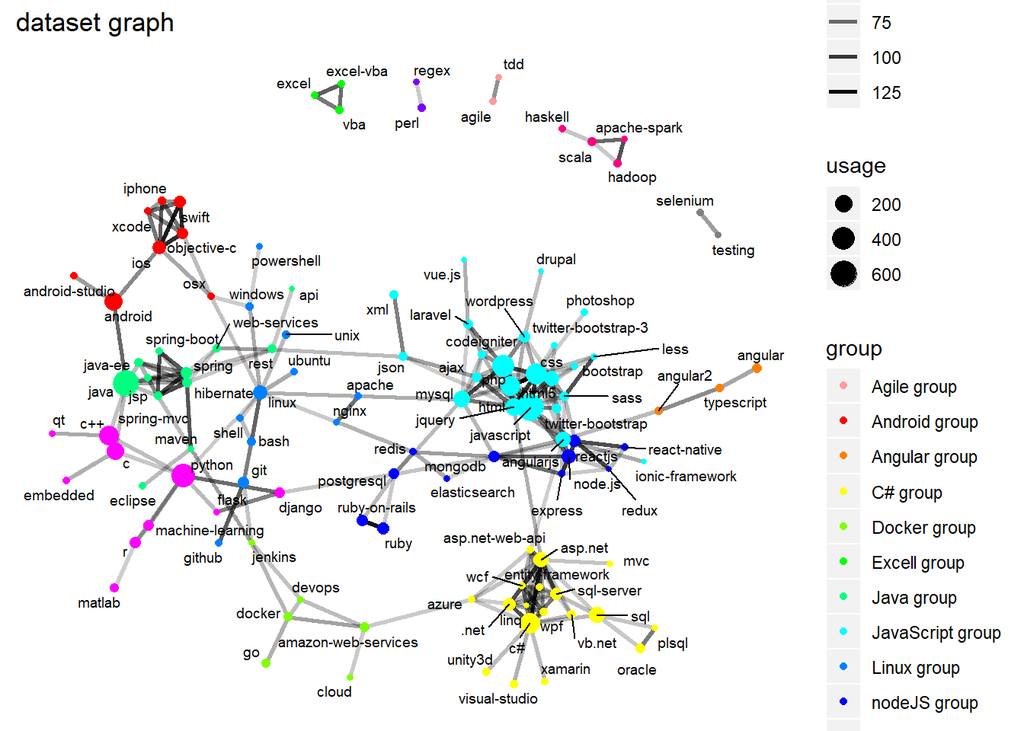

```r
g = graph_from_data_frame(edges1, directed = F, nodes1)
lay = create_layout(g, layout = "igraph", algorithm = "nicely")

ggraph(lay) +
  geom_edge_link(aes(alpha = connection), show.legend = NA, width = 1) +
  labs(title = "dataset graph") +
  geom_node_point(aes(color = group, size = usage), position = "identity", show.legend = NA) +
  geom_node_text(aes(label = name), show.legend = F, size = 2.5, repel = T) +
  theme(panel.background = element_blank(), axis.text = element_blank(),
        axis.ticks = element_blank(), axis.title = element_blank()) +
  scale_color_manual(values = c("#FF9999", "#FF0000", "#FF8000", "#FFFF00", "#80FF00",                                         "#00FF00", "#00FF80", "#00FFFF", "#0080FF", "#0000FF",                                         "#7F00FF", "#FF00FF", "#FF007F", "#808080"))
```

```r
#possiamo tradurre l'intero dataset in un grafo, i nodi corrispondono agli strumenti e la dimensione all'utilizzo. gli archi definiscono il livello di connessione (trasparenza) tra due strumenti. il colore definisce il gruppo di appartenenza di ogni strumento.
```

# DOMANDA 1) quanti strumenti conta ciascun gruppo, quali gruppi sono i piu numerosi?

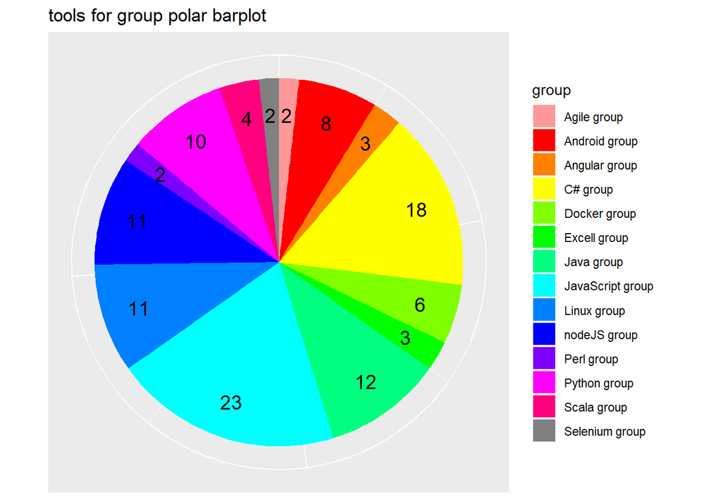

```r
nodes_n <- nodes1 %>%
  count(group) %>%
  arrange(desc(group))

ggplot(nodes_n, aes(x = "", y = n, fill = group)) +
  geom_bar(width = 1, stat = "identity") +
  scale_fill_manual(values = c("#FF9999", "#FF0000", "#FF8000", "#FFFF00", "#80FF00",                                         "#00FF00", "#00FF80", "#00FFFF", "#0080FF", "#0000FF",                                         "#7F00FF", "#FF00FF", "#FF007F", "#808080")) +
  labs(title = "tools for group polar barplot") +
  coord_polar(theta = "y", start = 0, direction = -1) +
  theme(axis.title = element_blank(), axis.text = element_blank(),
        axis.ticks = element_blank()) +
  geom_text(aes(x = 1.3, y = cumsum(n) - n/2, label = n), size=5)
```

```r
# Le famiglie di strumenti più utilizzate sono:
# - JavaScript group
# - C# group
# - Java group
```

# DOMANDA 2) quali sono gli strumenti utilizzati di più dagli sviluppatori?

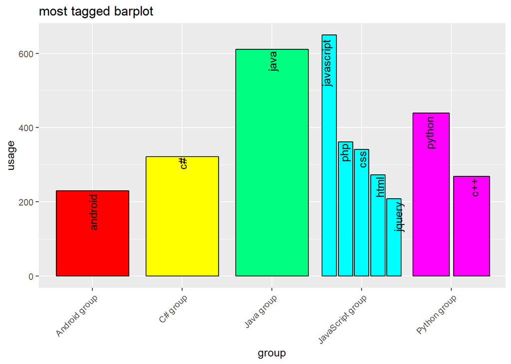

```r
nodes_most_tagged <- nodes1 %>%
  arrange(-usage) %>%
  head(10)

ggplot(nodes_most_tagged, aes(x = group, y = usage)) +
  labs(title = "most tagged barplot") +
  geom_col(aes(fill = group), color = "black", position = "dodge2", show.legend = F) +
  scale_fill_manual(values = c("#FF0000", "#FFFF00", "#00FF80", "#00FFFF", "#FF00FF")) +
  theme(axis.text.x = element_text(angle = 45, vjust = 1, hjust = 1)) +
  geom_text(aes(label = name), position = position_dodge2(width = 1), angle = 90,
            hjust = 1.1)
```

```r
# Gli strumenti più utilizzati sono:
# - JavaScript
# - Java
# - Python
```